# Problem Set 2- MA 611 US Gasoline Prices

2023-03-05

## Introduction:

In this notebook we are conducting an analysis for the Monthly average of US Gasoline prices from January 2000 to December 2019. In the data set we have two variables month and price.

## Import Dataset

Let’s define a time series data frame for the price variable of the given data set

```r
price.gs<-ts(GS$price,frequency = 12,start = c(2000,1))
```

## Gasoline Price Plot

Here we have generated a figure based on the data set, which indicates a noticeable increase in the price per gallon of gasoline from January 2000 to December 2019. There are some outliers in between 2008 to 2009 due to Economic Depression and then again in 2015 to 2017 due to oil crisis.

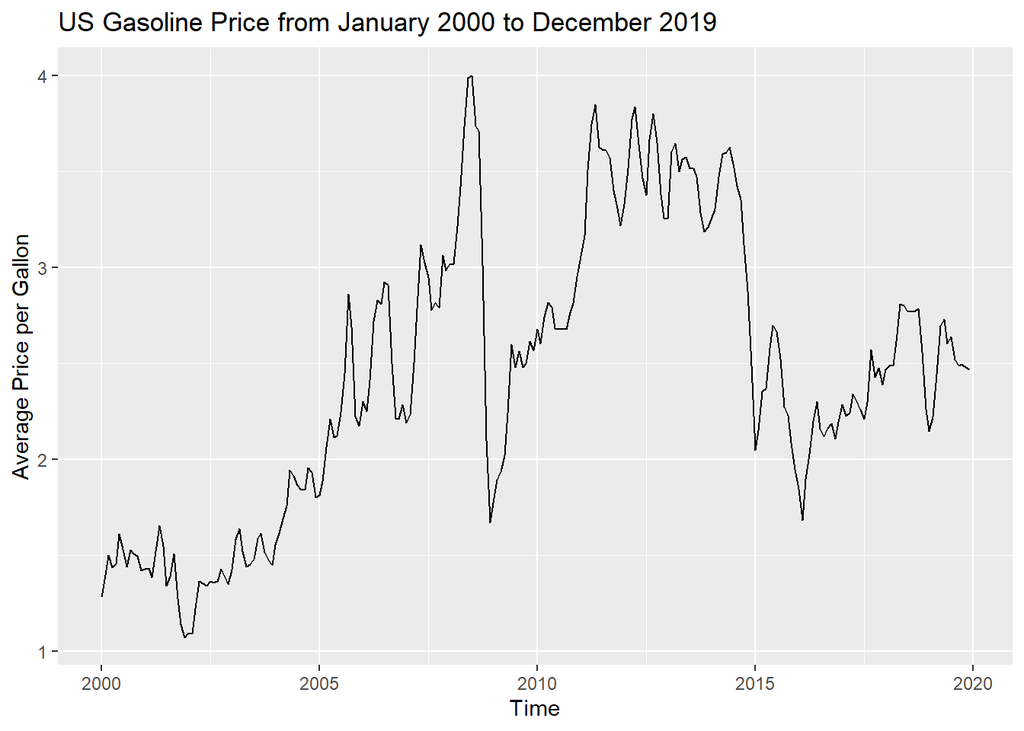

## Investigation into trend and seasoanality of US Gasoline Price

To analyze the dataset, the additive decomposition model was chosen, which is suitable for datasets with positive values where the seasonal effect tends to increase proportionally with the level. The model assumes that the seasonal values remain constant throughout the observed period.

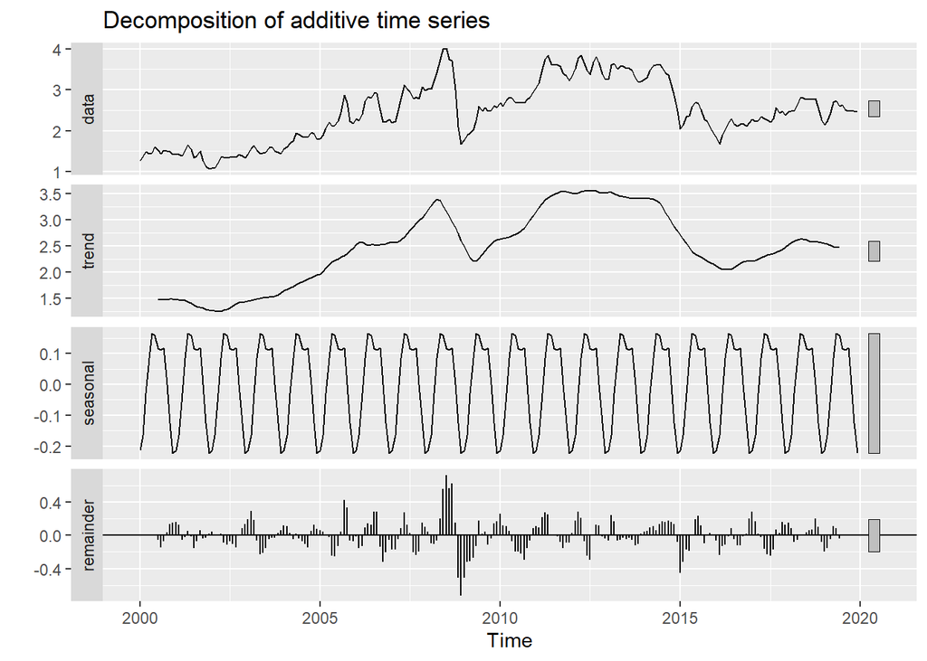

```
## [1] 0.9397677
```

```
## [1] 0.383217
```

The plot above illustrates the decomposition of the time series data into three components, namely trend, seasonal, and residual. The trend component indicates that the US gasoline prices exhibit an overall increasing trend over time, although there is no clear seasonality observed, the prices show an increase over the summer months and a decrease over the winter months. The residual component shows that there are random fluctuations present in the data. One of the advantages of using additive decomposition is that it helps in identifying and separating the underlying components of the time series, thus facilitating better understanding of trends and accurate forecasting. However, it should be noted that this method assumes that the trends and seasonal components are linear and that the residual component follows a normal distribution, which may not always be true for all datasets.

Based on the calculations, the trend strength is 0.9397677, and the seasonality strength is 0.383217. Therefore, it can be concluded that the time series exhibits a strong increasing trend and a relatively weak seasonality.

## STL Decomposition

In the STL decomposition method, we use local polynomial regression is used to estimate both trend and seasonality. The seasonal component is allowed to vary over time, and the trend-cycle can be controlled by the user.

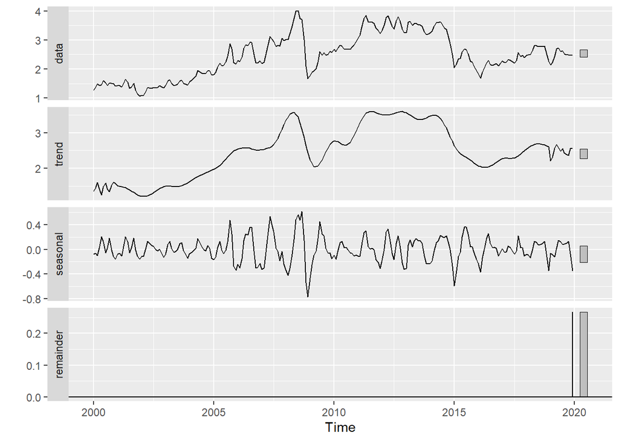

## Exponential Smoothening Methods

The method of exponential smoothing is extensively used for forecasting time series data, and it encompasses three primary types of models: Simple Exponential Smoothing (SES), Holt’s Linear Exponential Smoothing (Holt’s), and Holt-Winters’ Exponential Smoothing (HWES). To determine the most suitable model for the time series graph of the average price per gallon for regular gasoline (USD) plotted against dates in Mon-YY format, from January 2000 to December 2019, we can fit each model to the data and compare their respective performances.

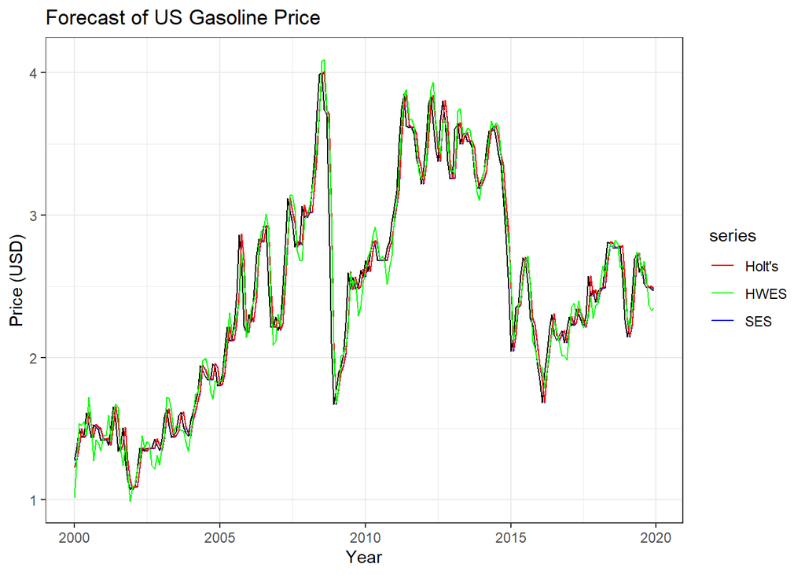

```
##                      ME      RMSE       MAE        MPE     MAPE      MASE
## Training set 0.00495859 0.1630034 0.1151209 0.04455751 4.895659 0.2832613
##                   ACF1
## Training set 0.4464568
```

```
##                        ME      RMSE       MAE        MPE     MAPE      MASE
## Training set 0.0003061865 0.1629677 0.1152003 -0.1580127 4.908324 0.2834566
##                   ACF1
## Training set 0.4470338
```

```
##                       ME      RMSE       MAE        MPE     MAPE      MASE
## Training set 0.002384623 0.1607737 0.1171362 0.09448552 5.174912 0.2882201
##                   ACF1
## Training set 0.3790482
```

The accuracy of the aforementioned model can be measured using different criteria, but in this case, the Root Mean Squared Error (RMSE) will be used to determine the best model. The model with the smallest RMSE value is considered the best model. Based on an RMSE of 0.1607, it can be concluded that the Holt-Winters’ Exponential Smoothing (HWES) model is the most suitable for predicting the US gasoline price.

## In-Sample Predictions Accuracy

```r
price.gs.snaive = snaive(price.gs,12)
price.gs.snaive.rmse=accuracy(price.gs.snaive)[2]
price.gs.naive= naive(price.gs,12)
price.gs.naive.rmse=accuracy(price.gs.naive)[2]
price.gs.meanf = meanf(price.gs,12)
price.gs.meanf.rmse=accuracy(price.gs.meanf)[2]

price.gs.snaive.rmse
```

```
## [1] 0.5360079
```

```r
price.gs.naive.rmse
```

```
## [1] 0.1633367
```

```r
price.gs.meanf.rmse
```

```
## [1] 0.7419654
```

Since there is a strong trend observed, the in-sample predictions’ RMSE values suggest that the naive strategy would be suitable for future predictions.

When comparing the RMSE values of Holt-Winters’ Model and Naive Strategy, it was found that Holt-Winters’ Model has a lower RMSE value, indicating that it is the better model for forecasting future values.

[figure not shown]